# STAT636: Homework 2. Graphical models and PCA

This homework is due Sept 22nd by 11:59 pm. It is scored out of 100 pts.

Load any packages you need here

```r
require(igraph)
require(dplyr)
```

#Introduction

For this assignment, let’s attempt to make a spam filter. Usually, this would involve a lot of text processing on a huge number of emails. In this case, someone has created a feature matrix for us. The feature matrix has rows given by individual emails and columns given by the number of each word or character that appears in that email, as well as three different numerical measures regarding capital letters (average length of consecutive capitals, longest sequence of consecutive capitals, and total number of capital letters).

# Problem 1. (10 pts)

Read in the R data set spam.Rdata (note: when the object is an Rdata file, use load(spam.Rdata) and read the documentation file spambase.Documentation.

```r
load('spam.Rdata')
Xfull = spam$XdataF

#Let's remove some of the non-word features
X = Xfull %>% select(contains('punc'),contains('cap'))

n =  dim(prcomp(X,scale=TRUE)$x)[1] #### Answer 1.1
p =  dim(prcomp(X,scale=TRUE)$rotation)[2] #### Answer 1.2

n
```

```
## [1] 4601
```

```r
p
```

```
## [1] 9
```

We have 4601 number of emails (observations). There are 9 number of words (features)

# Problem 2. Graphical models (40 pts)

## 2.1

Estimate a partial correlation graph with the bootstrap using 500 bootstrap draws (typically, we would use more, but this is a HW afterall). Draw an edge between two nodes if 0 is not in the bootstrap interval. Remember: Omega_jk = 0 means the two features are partially uncorrelated given every other feature.

```r
B = 500 #### Answer 2.1.1

Rhat_starOutput = array(dim=c(p,p,B))
for(b in 1:B){
    bootSamp      = sample(1:n,n,replace=TRUE)
    Xpc_star      = X[bootSamp,]
    Spc_star      = cov(Xpc_star)
    OmegaHat_star = solve(Spc_star)
    Rhat_star     = -diag(1/sqrt(diag(OmegaHat_star))) %*% OmegaHat_star  %*% diag(1/sqrt(diag(OmegaHat_star)))
    Rhat_starOutput[,,b] = Rhat_star
}


#### Answer 2.1.2: Print the lower 0.005 quantile of the bootstrap draws for the first 5 features only
Q_lower = apply(Rhat_starOutput,1:2, quantile, 0.005)
Q_lower[1:5,1:5]
```

```
##              [,1]         [,2]         [,3]         [,4]        [,5]
## [1,] -1.000000000 -0.013088804 -0.002882377 -0.009225987 -0.03047032
## [2,] -0.013088804 -1.000000000 -0.004474628 -0.094199887 -0.03684997
## [3,] -0.002882377 -0.004474628 -1.000000000 -0.040307697 -0.03617609
## [4,] -0.009225987 -0.094199887 -0.040307697 -1.000000000  0.06192415
## [5,] -0.030470319 -0.036849966 -0.036176089  0.061924150 -1.00000000
```

```r
#### Answer 2.1.3: Print the upper 0.995 quantile of the bootstrap draws#### Answer 2.1.3: produce a partial correlation graph using these bootstrap confidence intervals
Q_upper = apply(Rhat_starOutput,1:2, quantile, 0.995)
Q_upper[1:5,1:5]
```

```
##             [,1]        [,2]         [,3]        [,4]         [,5]
## [1,] -1.00000000  0.10610306  0.031195222  0.07388855  0.019643892
## [2,]  0.10610306 -1.00000000  0.072808167 -0.02978947  0.031984702
## [3,]  0.03119522  0.07280817 -1.000000000 -0.01808581 -0.009764364
## [4,]  0.07388855 -0.02978947 -0.018085814 -1.00000000  0.254275650
## [5,]  0.01964389  0.03198470 -0.009764364  0.25427565 -1.000000000
```

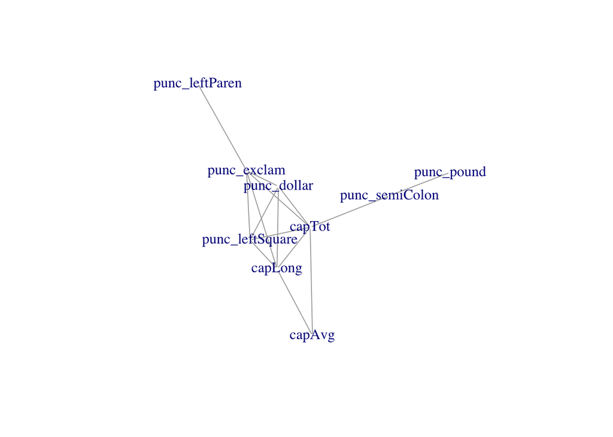

```r
#### Answer 2.1.4: produce a partial correlation graph using these bootstrap confidence intervals
noEdge = 0 > apply(Rhat_starOutput,1:2, quantile, 0.005) & 0 < apply(Rhat_starOutput,1:2, quantile, 0.995)

g = graph.adjacency(!noEdge , mode="undirected", diag=FALSE )
plot(g, layout=layout.auto,
     vertex.color='white',vertex.size=3,vertex.label=names(X),vertex.frame.color=NA)
```

## 2.2

Let’s investigate if the partial correlation graph interpretation can be strengthened to conditional independence in this case.

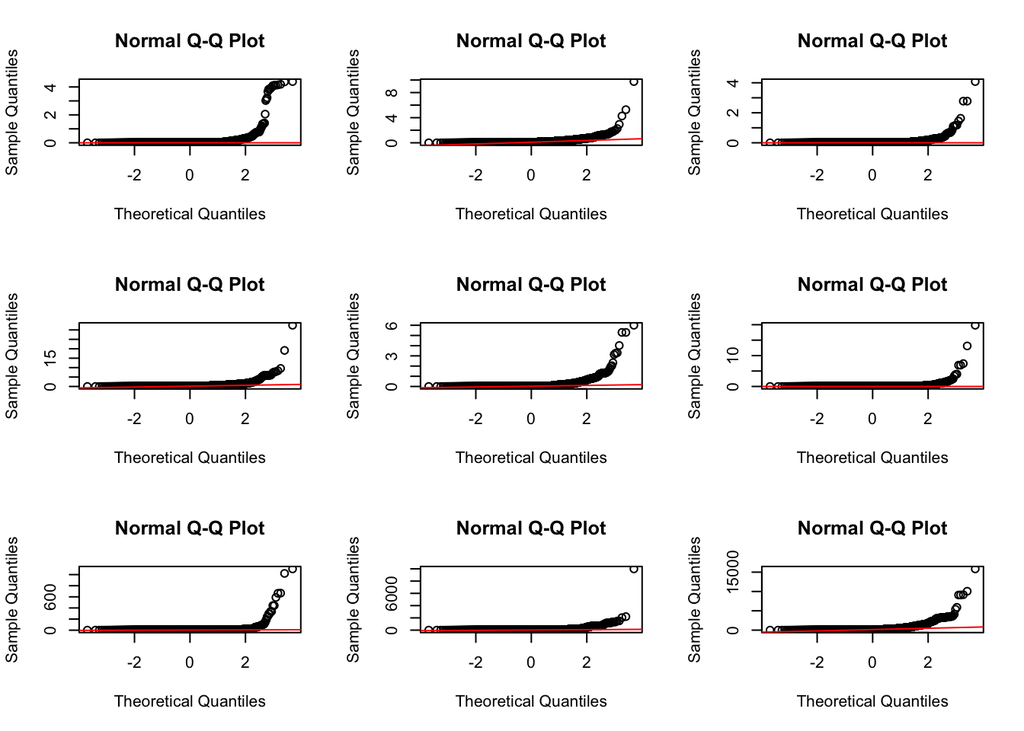

```r
#### Answer 2.2.1: Plot the QQplots looking at some of the marginal distributions
par(mfrow= c(3,3))
for(j in 1:p){
  qqnorm(X[,j])
  qqline(X[,j],col = 'red')
}
```

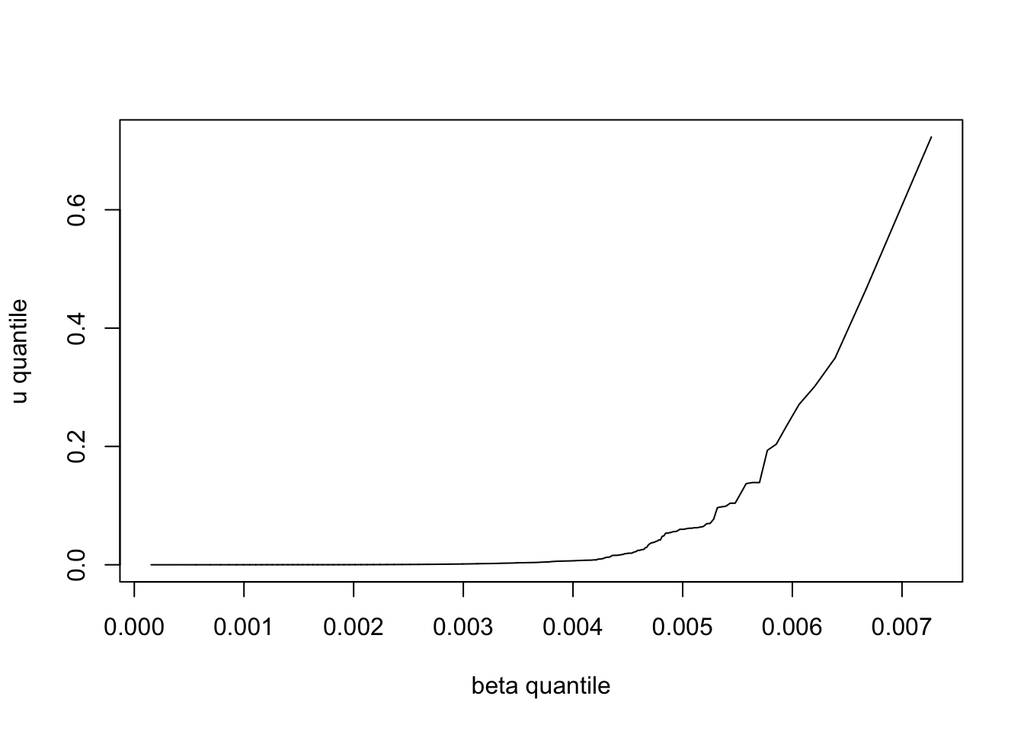

```r
#### Answer 2.2.2: Get the QQplot  with respect to the beta distribution
alp = (p-2)/(2*p)
bet = (n-p-3)/(2*(n-p-1))
a   = p/2
b   = (n-p-1)/2

probs = (1:n - alp)/(n - alp - bet +1)
quantiles = qbeta(probs,a,b)


Xcenter = scale(X, center=TRUE,scale=FALSE)
S=1/(n-1)*t(Xcenter) %*% Xcenter
Dsq = rep(0,n)
for(i in 1:n){
  Dsq[i] = t(Xcenter[i,]) %*% solve(S) %*% Xcenter[i,]
}
u = n * Dsq/(n-1)**2
par(mfrow=c(1,1))
plot(quantiles,sort(u),type='l',xlab='beta quantile',ylab = 'u quantile')
```

#### Answer 2.2.3

Looking at this data, is it reasonable to extend these results to conditional independence?

It is not reasonable to extend these results to conditional independence. Those results could be consedered as conditional independence only if marginal distributions are normal distributions. However, according to these Q-Q plots, we did not see the points forming a line that’s roughly straight. That means those data are not normal distribution, so it is not reasonable to extend these results to conditional independence.

#### Answer 2.2.4

Write down an interpretation of this graphical model (it shouldn’t be comprehensive, just interpret some aspect of the graphical model. One or two short sentences is fine).

We used beta quantile, which is a normal distribution, to compare with our data. As the points did not form a line that’s roughly straight, so we could check the normality byt this graphical model and knew that our data is not normal distributed.

## 2.3 (Extra Credit, this problem is optional and worth +10 pts)

Let’s instead attempt to transform our data to something more normal. For this section, let’s just look at the ‘capitalization’ features. Write up a function for finding a the multivariate Box-cox transformation, transform the data, and then re-make the marginal qqplots.

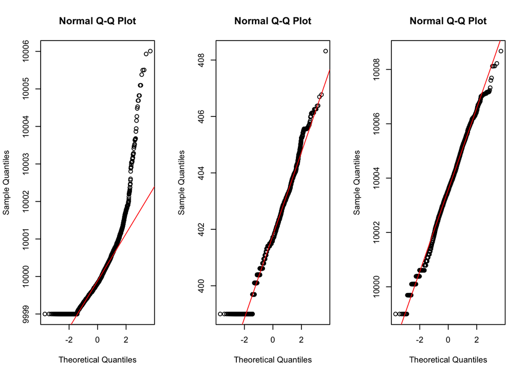

```r
X = Xfull %>% select(contains('cap'))
p = ncol(X)

S_lamF = function(lam, X){ #### Answer 2.3.1. Compute the sample covariance matrix on the transformed data
    Xcenter = scale( t( (t(X) ** lam)/lam - 1 ) ,center=TRUE,scale=FALSE)
    return(1/(n-1)* t(Xcenter) %*% Xcenter)
}
logLikeF = function(lam, X){ #### Answer 2.3.2. Compute the sample covariance matrix on the transformed data
    S_lam = S_lamF(lam, X)
    return(-n/2 * log(det(S_lam)) + sum( (lam - 1) * apply(log(X),2,sum)) )
}

lam = c(0.0001, 0.0005, 0.001,.0025,.005,.01,.05)#these values are due to the type of skew
lamGrid = expand.grid(lam,lam,lam)
out = apply(lamGrid,1,logLikeF, X)

lambdaHat = unlist(lamGrid[which.max(out),])

Xtrans = t( (t(X) ** lambdaHat)/lambdaHat - 1 )

par(mfrow= c(1,3))
for(j in 1:p){
  qqnorm(Xtrans[,j])
  qqline(Xtrans[,j],col = 'red')
}
```

I found the transformation parameter lambda to be 10^{-4}, 0.0025, 10^{-4}.

# Problem 3. PCA (50 pts)

Let’s look at the ‘stock_prices.csv’ data. These contain normalized stock prices for five different companies over a period of weeks, three of which are banks (JP Morgan, Citibank, and Wells Fargo) and two of which are oil companies (Shell and Exxon Mobil).

## 3.1

Get the PCA of this data, but only center by the mean, don’t scale by the standard deviation. Make a scree plot of the proportion of variance explained against principal component (PC) number. How many principal components would you recommend in order to retain 90% of the variance?

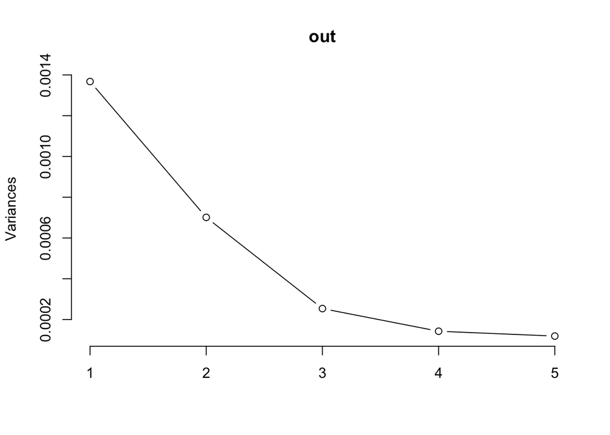

```r
stockprice_data = read.csv("stock_prices.csv")
#df = stockprice_data
SPCenter = scale(stockprice_data,scale=FALSE)
svd.out = svd(SPCenter)



out = prcomp(stockprice_data,scale=F)
pcs = out$rot
scores = out$x



#### Answer 3.1.1 Make a scree plot
screeplot(out, npcs = min(10, length(out$sdev)),
          type = c("lines"),
          main = deparse(substitute(out)))
```

```r
nPCs = min(which(cumsum(out$sdev**2/sum(out$sdev**2))>0.9)) #### Answer 3.1.2 replace this value with the number of retained PCs
```

I will retain 4 PCs.

## 3.2

Make a scatterplot of the first two principal component scores. Which weeks have the minimum and maximum values of PC 1?

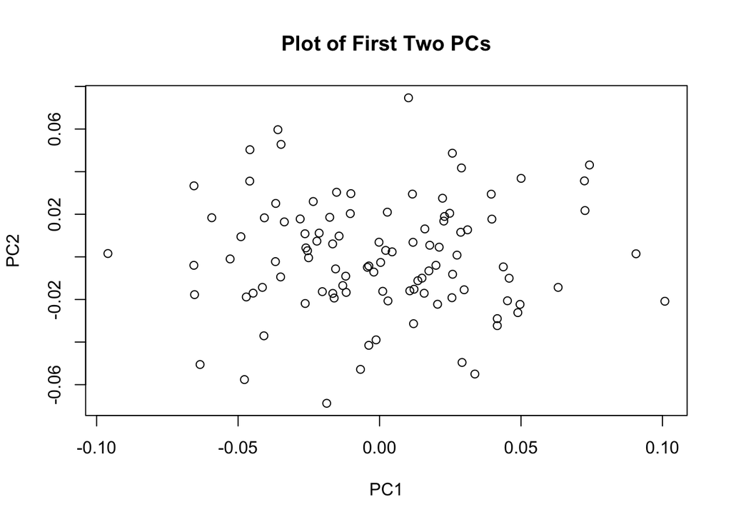

```r
#### Answer 3.2.1: Make a scatter plot
#install.packages('ggfortify')
#library(ggfortify)
#autoplot(X)

plot.stockp = function(X,zlim=c(-1,1)){
  cols = gray.colors(100)[100:1]
  image(matrix(X,nrow=16)[,16:1],col=cols,
        zlim=zlim,axes=FALSE)
}

plot(scores[,1],scores[,2],xlab = 'PC1', ylab = 'PC2', main = 'Plot of First Two PCs')
```

```r
#df = stockprice_data
#autoplot(prcomp(df))

minPC1score = which.min(scores[,1])
minPC1score
```

```
## [1] 56
```

```r
maxPC1score = which.max(scores[,1])
maxPC1score
```

```
## [1] 63
```

```r
weekWithMinPC1score = minPC1score#### Answer 3.2.2
weekWithMaxPC1score = maxPC1score#### Answer 3.2.3
```

The week with the minimum PC1 score is the observation 56 and the maximum PC1 score is 63.

#### Answer 3.2.4

Comment on how these weeks compare to each other.

Through the plot of first two PCs, we could see the similarities between those weeks. For example, we could find some of weeks have higher scores of PC1 and some of them have higher scores on PC2. Therefore, according to the plot, we could see who are similar.

## 3.3

Now run PCA again but centering and scaling the data. Find the percent variance explained by the first ‘nPCs’ for the unscaled PCA and for the scaled PCA.

```r
#out = prcomp(stockprice_data,scale=F) #not scaled and centered yet

eigs = out$sdev^2
rbind(
  SD = sqrt(eigs),
  Proportion = eigs/sum(eigs)*100,
  Cumulative = cumsum(eigs)/sum(eigs))
```

```
##                   [,1]        [,2]       [,3]       [,4]       [,5]
## SD          0.03698213  0.02647942 0.01593118 0.01194163 0.01090352
## Proportion 52.92606584 27.13329846 9.82158416 5.51840003 4.60065151
## Cumulative  0.52926066  0.80059364 0.89880948 0.95399348 1.00000000
```

```r
#scaled and centered
out_sc = prcomp(stockprice_data,center = TRUE, scale = TRUE)
eigs_sc = out_sc$sdev^2
rbind(
  SD_sc = sqrt(eigs_sc),
  Proportion_sc = eigs_sc/sum(eigs_sc)*100,
  Cumulative_sc = cumsum(eigs_sc)/sum(eigs_sc))
```

```
##                     [,1]       [,2]       [,3]      [,4]      [,5]
## SD_sc          1.5611768  1.1861756  0.7074693 0.6324805 0.5051434
## Proportion_sc 48.7454625 28.1402532 10.0102550 8.0006317 5.1033977
## Cumulative_sc  0.4874546  0.7688572  0.8689597 0.9489660 1.0000000
```

```r
percVarExplainedUnscaled = 0.95399348*100 #### Answer 3.3.1
percVarExplainedScaled   = 0.9489660*100 #### Answer 3.3.2

percVarExplainedUnscaled
```

```
## [1] 95.39935
```

```r
percVarExplainedScaled
```

```
## [1] 94.8966
```

The percent var explained unscaled is 95.399348 and the percent var explained scaled is 94.8966

#### Answer 3.3.3

Why do you think there isn’t much difference between the scaled and unscaled PCA for this data set?

As a general rule, we use scale if the features are measured in different units. If features are in the different units, our results may be distorted, and that’s why we need to scale them. However, in this case, those stock prices are in the same units, so there isn’t much difference between the scaled and unscaled PCA for this data set.